# Sensitivity analysis of model parameters

2023-12-14

### Model

$$B = d \left [ \frac{H}{2} \left ( A_{basal} + A_{half} \right ) \right
]^{z},$$
where $B$ is the biomass calculated by the allometric equation, $d$ is the bulk density of the plant species, $H$ is the measured height of the plant, $A_{basal}$ and $A_{half}$ are the basal area and the area at half the height of the plant, respectively; and $z$ is the power coefficient of a power law.

### Problem

In Perronne et al. (2020), the authors assign a value of 1.96 to $d$ and a value of $2/3$ to $z$; however, we do not know how those parameters interact with each other.

### Approach

To solve this, we perform a sensitivity analysis in which we modify the values of $d$ and $z$ within a certain range, described below. Importantly, to simplify the allometric equation and do a clear sensitivity analyses that works independently of the field data, we opt to include the parameter $x$ as:

$$x = \left [ \frac{H}{2} \left ( A_{basal} + A_{half} \right ) \right ],$$
meaning that all allometric measurements are summarized now by $x$. Thus, the equation used for our sensitivity analysis is the following:

$$B = dx^{z}$$

At this point, we assign the following values to the different parameters in the model:

- for $d$, values of 0.98, 1.47, 1.96, 2.45, 2.94, 3.43, 3.92;
- for $x$, values of 0, 25, 50, 75, 100, 125, 150, 175, 200, 225;
- for $z$, values of 0.1, 0.11, 0.12, 0.13, 0.14, 0.15, 0.16, 0.17, 0.18, 0.19, 0.2, 0.21, 0.22, 0.23, 0.24, 0.25, 0.26, 0.27, 0.28, 0.29, 0.3, 0.31, 0.32, 0.33, 0.34, 0.35, 0.36, 0.37, 0.38, 0.39, 0.4, 0.41, 0.42, 0.43, 0.44, 0.45, 0.46, 0.47, 0.48, 0.49, 0.5, 0.51, 0.52, 0.53, 0.54, 0.55, 0.56, 0.57, 0.58, 0.59, 0.6, 0.61, 0.62, 0.63, 0.64, 0.65, 0.66, 0.67, 0.68, 0.69, 0.7, 0.71, 0.72, 0.73, 0.74, 0.75, 0.76, 0.77, 0.78, 0.79, 0.8, 0.81, 0.82, 0.83, 0.84, 0.85, 0.86, 0.87, 0.88, 0.89, 0.9, 0.91, 0.92, 0.93, 0.94, 0.95, 0.96, 0.97, 0.98, 0.99, 1.

And we create a data frame including all the combinations between the values of each parameter (6370 different cases) and their predicted value of biomass, $B$.

### Dataviz

Now, some visualizations to understand the relationship between the different parameters.

#### $x$ and $z$

The relationship between $x$ and $z$ for values of $d$ = 0.98, $d$ = 1.96, and $d$ = 3.92, looks like this:

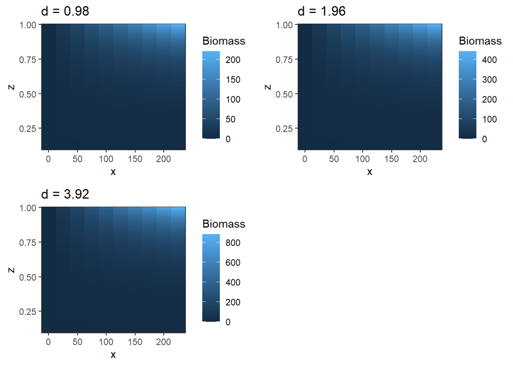

(…)

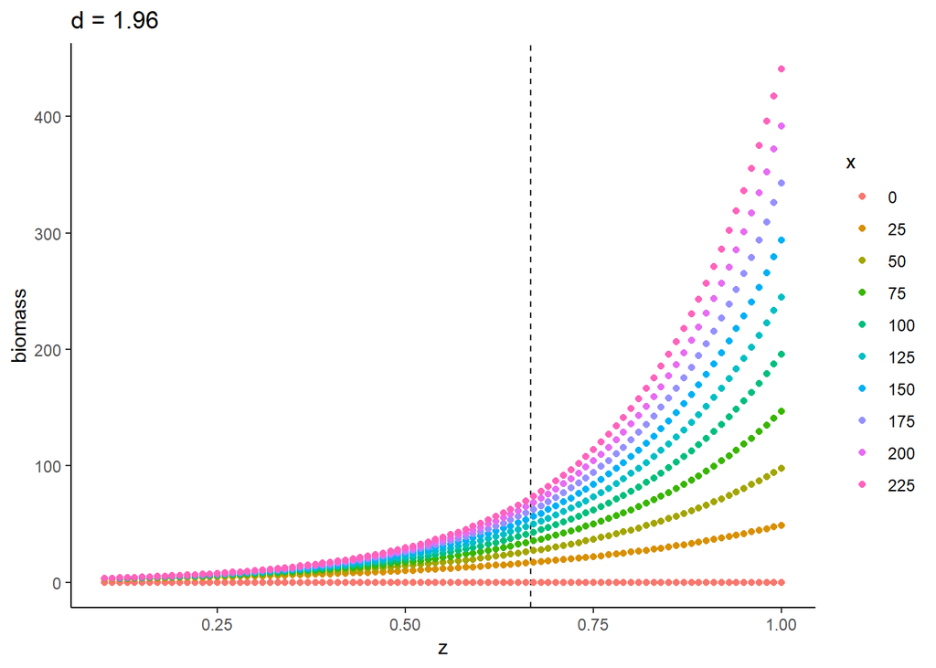

(…)

### References

Perronne, R., F. Jabot, and J. Pottier. 2020. [Inter- and intraspecific variability of plant individual growth and its role on species ranking in grasslands](https://doi.org/10.1093/jpe/rtaa021). Journal of Plant Ecology 13:378–386.